# Urbhealth: Connecting Urban Planning and Community Health

Author

Dylan Mach, Andrew Mitchell

# Introduction

With the advance of widely accessible public health and urban design datasets, people have even greater access to data from the general public, making large datasets detailing certain community health metrics open to the world . However, this data is often not easily accessible, making it quite difficult to peruse the millions of dataset provided by the government to figure out what exactly has caused a significant portion of the community’s health outcomes. Through this project, this data will be searched, parsed, and analysed through regression analysis and an average health metric index algorithm to give us a greater insight into what health metrics are the most significant in terms of community health outcomes.

## Indicator Patterns

Numerous urban measures used in indicators have established correlations with public health outcomes. The amount of green space in urban areas has been linked to improved mental health and encouraged more physical activity, while also decreasing community violence and death rate. Implementation of supermarkets (sources of fresh food) has accompanied lower food insecurity rates, lower dependence on federal food aid, and improved overall well-being health-wise. Widespread community accessibility to public transport has been linked to lower rates of obesity, decreased pollutant and emission concentrations, and lowered other prominent cardiovascular and mental health ailments (Litman, 2016). While these indicators can have strong correlations with health outcomes, causality cannot be attributed to them, as these studies are observational and cannot establish causality. However, these studies highlight measured relationships between urban planning and public health that can be communicated and utilised to foster prioritised decision-making. Additionally, these are commonly utilized indicators in UHI development due to their ability to be measured, widespread availability of data, and accurate depictions of public health. It is also important to avoid considering these indicators to have direct impact on health outcomes, as indicators influence a variety of factors that contribute to health outcomes.

A purpose of many existing UHIs in literature is to simplify decision-making in a complex field (urban planning and its ties to public health), causing decisions to be streamlined and efficient. This simplification occurs by representing relationships and correlations as numerical values. However, in order to do so successfully, UHIs must logically account for complexities in the field; many UHIs did not explicitly mention a methodology to do so. Additionally, indicator selection for current UHIs appears to be influenced by the difficulty of obtaining such indicators, making data that is easier to measure and analyze more likely to contribute to UHIs.

## Indicator Development - Methodologies

Sometimes, weights are simply chosen on a relativistic scale, which is most often based on perceived significance and data reliability. Yale’s Environmental Performance Index subjectively perceives different indicators and their relationships with environmental status and policy, as well as weighing in data reliability (Block, 2024). For instance, weights are decreased for an indicator that has only one year of data or rendered more obsolete compared to other indicators with respect to its impacts on a certain outcome. Weights can also be attributed to statistical measures, which analyze indicator purpose to a more pure, objective lens. The Human Development/Poverty Indices in India determines weights through factor loadings, a measure of correlation between indicators and the outcome sourcing from SPSS analysis (Antony, 2007). This increases the significance of indicators that are more closely related to health outcomes compared to indicators that aren’t.

A more unique yet solid indicator construction technique is the Mazziato-Pareto Index (MPI) technique, which uses an arithmetic mean modulated by a penalizing factor. An arithmetic mean allows for non-arbitrary index determination, while the penalty adjustment (derived from indicator variability) prevents high indicator values from overshadowing low indicator values. Another technique is the Alkire-Foster (AF) method, which multiplies incidence by intensity (UNDP, 2023). Indicators are portrayed as binary, with specific hard thresholds marking whether or not the indicator contributes or does not contribute to the incidence. For example, in the Multidimensional Poverty Index, the poverty rate threshold is set such that only areas above that threshold would count - there is no soft gradient. Incidence is also determined by a hard threshold. Incidence is a proportion of areas that have a certain amount of indicators above their respective thresholds. Intensity is the average number of indicators above thresholds among areas that count toward incidence. The AF method provides a holistic viewpoint of not only where areas are affected, but how broader areas of studies are faring.

Regardless, most UHI development methodologies involve a filtration process to determine a concise, representative set of urban indicators to explain health trends (Pineo, 2018). Indicator filtration typically includes considerations of data availability, data recency, and clear purposes of data measurement (to avoid ambiguity in future interpretation). After a set of indicators is selected, weights are assigned to indicators in order to differentiate levels of impact on health outcomes (although weights can also be set equal to avoid limitations). Data values for each indicator are used in correspondence with their weights to create individual indicator values for each geographic area. (Pineo, 2017)

# Methods

We first selected an optimal geographic scale (based on a territorial division). Scale is important to prevent sweeping over-generalisations (from a broader scale) or cases of overfitting (from a narrower scale). This indicated that ZIP codes, census tracts, or census blocks would be the most optimal scale of analysis. ZIP codes were ultimately rejected for the scale of analysis because they centre around mailing statistics, which could poorly explain demographic trends. Census blocks were not chosen because of high chances of overfitting and the lack of data accessibility (for both urban indicators and public health statistics).

## Data Processing

We subjectively selected response datasets under two main criteria: 1) They were common diseases in urban areas and 2) Their frequencies did not have high amounts of genetic influence (although some genetic influence is unavoidable). This criteria was selected in order to prevent unnecessary analysis on diseases that were not impacted or related to aspects of urban planning.

Additionally, to objectively center the analysis around urban areas, only urban and suburban tracts were selected. Rural tracts were eliminated based on a tract index derived from population and population density, which was established by the United States Department of Transportation’s Urbanicity Index (BTS, 2024). Rural tracts were identified as tracts that were not Urban Areas (UAs, over 50,000 people) or Urban Centers (UCs, between 2,500 and 50,000 people), meaning that they contained less than 2,500 people. This round of data filtration was also performed in Excel and resulted, alongside with imputation of NaN values, in 47092 census tracts across the nation. Additionally, through a triangular correlation matrix, indicators that shared major multicollinearity problems with other indicators (R2 > 0.90) were eliminated.

Data was collected on the census-tract scale, all from the year 2019 (data collected decenially were from 2010 instead of 2020 to avoid COVID-19 complications in the data).

## Data Description

Explanatory datasets were sourced from the National Neighborhood Data Archive at the University of Michigan (NaNDA), the US Census Bureau, the United States Department of Agriculture (USDA) Food Access Research Atlas, the United States Bureau of Transportation Statistics Local Area Transportation Characteristics for Households (LATCH), the Housing and Transportation Affordability Index (H+T), and the University of Minnesota’s Access Across America. NaNDA provided data on tract proportions of public transportation stops (stops) and park areas (park_area). The US Census Bureau provided a common thread of identification data between datasets, including state and population. The USDA Food Access Research Atlas provided data about food insecurity, measuring the proportion of a tract who had low access to food in a 0.5-mile radius (halfshare), as well as the percentage of families in a tract with low/no access to private vehicles (hunv). The LATCH provided data on vehicular usage, primarily in the form of person-trips (ptrp), the number of trips by one person in any form of transport in a day, or vehicle-miles (vmiles), the number of miles driven by a vehicle in a day multiplied by the passenger quantity. H+T provided data on employee gravity (emp_gravity), the total number of jobs in a tract divided by the square of its distance from the tract centroid, and the annual income spent on transportation and housing (ht_ami). Data from the Access Across America dataset related to job accessibility with respect to transit (transit), which measures the number of accessible jobs a person can reach through public transit services within an 1800-second threshold (a subjective selection that represents a tolerable commute time for an average worker).

To develop a regression model, Python was utilised to create a program that takes a certain number of metrics and compares them to determine the statistical significance of proportionality and means between variables. Then, semi-partial correlation was utilised to find individual Pearson r-values that would eliminate covariate influence on the analysis. This variable analysis led to the development of the Urbhealth index.

### Person-trips

The measure of person-trips was abbreviated to be `ptrp` throughout this analysis. A person-trip is defined by the United States Bureau of Transportation Statistics Local Area Transportation Characteristics for Households Survey (LATCH) as a trip made by a person in any mode of transportation – trips are generally subdivided into the categories of personal errands, social, work, church/school, work-related-business, and other. We utilized the LATCH dataset that was produced in 2017.

### Vehicle-miles

The measure of vehicle-miles was abbreviated to be `est_vmiles` throughout this analysis. A vehicle-mile is defined by the United States Bureau of Transportation Statistics LATCH Survey to be one vehicle traveling one mile. This means that this dataset is passenger-independent, as more than one passenger can ride in the same vehicle. (However, adjustments for trains and other multi-car modes of transportation are included.) We utilized the LATCH dataset that was produced in 2017.

### Parks by Census Tract

The measure of the proportion of a census tract’s area that is designated to be a park was abbreviated to be `ParkAreaProportion`. This measure is produced by the National Neighborhood Data Archive (NaNDA) at the University of Michigan. This dataset utilized the census TIGER/Line shapefiles (2010) to accurately delineate census tract boundaries and, through ArcGIS, utilized a pairwise intersect to merge enclosed areas from those shapefiles and the ParkServe shapefiles, which provided geospatial data on parks. Then, area inside of enclosed areas that also include parks from the ParkServe shapefiles were used to calculate the proportion of parks per census tract (as a percentage) utilized in this analysis. We utilized the NaNDA dataset that was produced in 2018.

### Public Transit Stops by Census Tract

The measure of the amount of public transit stops within a census tract was abbreviated as `StopsperSqMile` throughout this analysis and was also sourced from NaNDA. Census tract delineation for this dataset utilized the TIGER/Line Shapefiles (2010), and data for the public transport stops was sourced from the National Transit Map (NTM). This data allowed for sufficient information to derive the count and density of transit stops within a census tract. We utilized the NaNDA dataset that covered the years between 2016 and 2018.

### Housing and Transportation Area Median Income

The measure of Housing and Transportation Area Median Income was abbreviated to `ht_ami` throughout this analysis. ht_ami is calculated to be the percentage of the income for the regional typical household (which is also the area median income) that is attributed to both housing and transportation costs. This calculation derives from the H+T Affordability Index. A regional typical household is defined to be a household income that is calculated as the median of the region. Additionally, for these households, regional average household size and commuters per household values are utilized. We utilized the dataset produced in 2022, which relies on 2019 data for its production.

### Employee Gravity

The measure of employee gravity was abbreviated to `empgravity` throughout this analysis. Employee gravity is defined by the H+T Affordability Index as the total number of jobs in a tract divided by the square of its distance from the tract centroid. The tract centroid is the approximate geographic center of the geospatial census tract polygon. We utilized the dataset produced in 2022, which relies on 2019 data for its production.

### Noise Exposure

The measure of noise exposure was specifically chosen to represent the population-weighted noise exposure, and is abbreviated `nsaverage` throughout the analysis. We utilized a formula to manually calculate the population-weighted noise exposure from the National Transportation Noise Exposure dataset provided by the University of Washington Deohs School of Public Health. This formula, instead of using specific decibel ranges of noise exposure, provides a single metric for each census tract by combining a weighted average of all of the decibel ranges. We utilized the dataset that was produced within a 2023 paper.

## Initial data scaling and processing

To begin data analysis, a level of territorial division had to be selected uniformly across the US. While states, counties, and city limits were too general and would not allow analysis of individual neighborhood and urban areas, census blocks were too specific and would provide overfitted data. Census tracts were chosen over ZIP codes because ZIP codes center around mailing and delivery statistics, making them a more inaccurate marker of demographic trends.

## Feature Selection

We computed the mutual information values in R by using the `condinformation` function from the `infotheo` library. By setting up a nested for loop to cycle through both indicator and health factor subsets, we compute all permutations of mutual information, and can consolidate those data points into a matrix as shown below:

We also noted that there were no standard thresholds for mutual information values in studied scientific literature: “In general, it is not straightforward to develop guidelines for cut-offs of MI indicating weak or strong relationships” (Young, 2023). The only indication of relative mutual information is when MI values are zero, which indicates the absence of relationships between the analysed independent variable and dependent variable. Therefore, we could not create a substantiated threshold for reference. Thus, we determined that the majority of dependent variable information can be explained, on the line graph, by the variables with MI values above the sharpest bend of the graph. This can be determined by inspection.

However, solving for MI values only rejects any variability in mutual information between states, as we consider states as a hierarchical variable later. Thus, we must use conditional information, where we can calculate the amount of information that one variable provides over the other when we are given a fixed value for a third variable; in this situation, the third variable is the state. By running a similar function in R with calculating MI values, except adding a function to condition on the “States” variable, we produced the following conditional mutual information (CMI) matrix:

Here, we also notice similar patterns to the MI value matrix, where the variables est_vmiles and est_ptrp are able to explain the most information for each health disease factor. We deemed this result to be reasonable as conditioning on the state should not heavily alter the amount of information explained.

## Model and Parameter Selection

The model that we chose to calculate our UHI, Urbhealth, was a hierarchical generalised additive model. First, we wanted to select a model that represented non-linear trends, which allows for non-linear relationships in data to be explored. Therefore, we selected an HGAM, which allowed us to form a custom polynomial as a summation of multiple non-linear functions for the individual indicators. A hierarchical version of a generalised additive model (GAM) was selected in order to establish hierarchies by state. We chose to establish these state hierarchies to produce a single common smoother among every model. in addition to state smoothers that have equal wiggliness. We selected this HGAM methodology to acknowledge that states should have similar template model shapes (as there are no drastic differences in disease frequencies across the United States); however, we also allowed for state-level smoothers to incorporate smaller variations in model shapes that could differentiate across states.

Since all variables studied are considered continuous (except the State variable, which when quantitatively indexed, is discrete), it is appropriate to represent all of the individual indicators as smooth functions, by the s() function in the “mgcv” library in R. Smooth functions were assigned to each urban indicator with the default bs = “tp” function, which produces thin plate splines (TPS). We selected TPSs as a model because they are “ideal for examining the combined effect of two continuous predictors on a single outcome”, which facilitated modelling between multiple urban indicators and individual health factors.

In order to factor in the State variable in the model, which is a discrete variable when indexed, we utilized the factor smooth (“fs”) model parameter within the mgcv library, where bs = “fs”. This model parameter was a modification of the proposed HGAM model parameters established by Pederson in the context of a global smoothing parameter that creates generalised shape while also accounting for geographic heterogeneity through smaller, adjusting smoothing terms for individual state groups (Pederson, 2019), which aligns with our goals of model construction stated in the above paragraphs in this section.

Multicollinearity, or significant evidence of correlation between multiple explored independent variables, was investigated by observing concurvity, a non-linear analogue to the variance inflation factor (VIF). We deemed it improper to use multicollinearity analysis for the HGAM model because multicollinearity observes overlapping linear trends, while this model utilized non-linear trends. This increases the chance of false multicollinearity analysis values that do not accurately reflect on the model shape; utilizing concurvity accommodates for that issue. Concurivty produces three separate analyses estimates by examining a ratio of a decomposed basis model `g` to the original smooth model `f` if `g` consists of the basis functions of all other variablex except the one analysed. Although there is no prevalent established threshold for model quality based on concurvity value, some sources indicate a threshold of 0.5 or lower indicates a viable model with low non-linear multicollinearity (Ramsay, 2003). Although the concurvity function produces three separate analyses, the “estimated” analysis was used for accurate model analysis, while the “worst” analysis was used for a rough benchmark of model performance.

Statistical significance in this project was analysed within the scholarly social sciences parameters, in which a standard R^2 between 0.10 and 0.50 is acceptable as long as each explanatory variables is significant relative to the response variable (p < 0.05).

Most states were not placed in clusters in order to maximize homogeneity in samples. However, ones that had low population/amount of census tracts were placed in geographic clusters.

# Results

## Descriptive Statistics

Table 1 displays the descriptive statistics for the data utilized in this statistical analysis. There were a total of 39,344 census tract samples that were utilized in this analysis. All disease statistics are reported in decimal proportions. Units for other data points are described in the Data Description section.

```r
dvs <- c('CHD', 'Depression', 'COPD', 'DIABETES', 'HIGHCHOL', 'BPHIGH', 'Obesity')

data <- read_excel("/Users/dmach/Downloads/clean.xlsx") # non-cleaned data

#rename(data, PAProp = "ParkAreaProportion", StopsSqMile = "StopsperSqMile")

ivs <- c('ParkAreaProportion', 'StopsperSqMile', 'est_vmiles', 'est_ptrp', 'ht_ami', 'emp_gravity', 'nsaverage')

data <- data |>
    dplyr::select(!starts_with("Unnamed")) |> # remove extra columns
    filter(State != "FL") |> # remove Florida data
    filter(emp_gravity < 300000) # remove emp_gravity single outlier

data$est_ptrp <- na_if(data$est_ptrp, 0) # replace 0 with NA
data$ht_ami <- na_if(data$ht_ami, 0)
data$TractID <- factor(data$TractID) # convert to factor variable
data$State <- factor(data$State)

data[dvs] <- data[dvs] / 100 # convert to percentage 0-1

data <- drop_na(data) # drop missing data

# knitr::kable(summary(data), format = "pipe")
table1 <-
  data |>
  tbl_summary(
    statistic = all_continuous() ~ "{mean} ({sd})",
    include = c(ivs, dvs)) |>
  modify_caption("Table 1. Descriptive statistics of data.")
table1
```

Table 1. Descriptive statistics of data.

| **Characteristic** | **N = 39,344**<sup>1</sup> |
| --- | --- |
| ParkAreaProportion | 0.04 (0.08) |
| StopsperSqMile | 16 (27) |
| est_vmiles | 34 (11) |
| est_ptrp | 8.16 (1.08) |
| ht_ami | 46 (11) |
| emp_gravity | 42,784 (44,931) |
| nsaverage | 53.42 (2.45) |
| CHD | 0.055 (0.018) |
| Depression | 0.21 (0.04) |
| COPD | 0.065 (0.025) |
| DIABETES | 0.11 (0.04) |
| HIGHCHOL | 0.34 (0.04) |
| BPHIGH | 0.31 (0.07) |
| Obesity | 0.34 (0.07) |

<sup>1</sup> Mean (SD)

## Mutual Information and Conditional Mutual Information

As mentioned in the Feature Selection section of the Methods section in this paper, the objective, quantitative measures of both mutual information (MI) and conditional mutual information (CMI). Figures 2.1 and 2.2 indicate the corresponding heatmaps for MI and CMI, respectively.

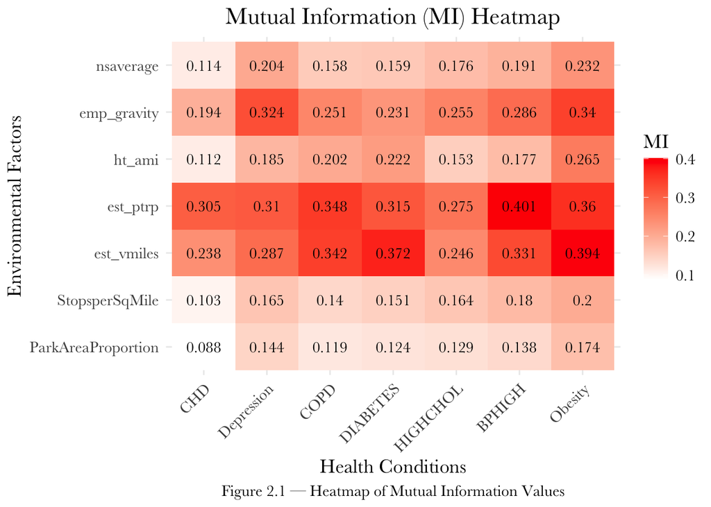

```r
nbins <- sqrt(NROW(data))

numeric_cols <- c(ivs, dvs, 'Lat') # Columns to discretize
discretized_data <- data

for (col in numeric_cols) {
  discretized_data[[col]] <- discretize(discretized_data[[col]], disc = "equalwidth", nbins = nbins)
}

cor_matrix <- cor(discretized_data[numeric_cols], use = "complete.obs")

# Print correlation matrix to understand relationships
# print(cor_matrix)

for (dv in dvs) {
  for (iv in ivs) {
  cond_info <- condinformation(discretized_data[[iv]], discretized_data[[dv]], discretized_data[['State']])
  # print(paste("Conditional Information for", iv, "and", dv, ":", cond_info))
  }
}
cmi_values <- matrix(0, nrow = length(ivs), ncol = length(dvs))
rownames(cmi_values) <- ivs
colnames(cmi_values) <- dvs

mi_values <- matrix(0, nrow = length(ivs), ncol = length(dvs))
rownames(mi_values) <- ivs
colnames(mi_values) <- dvs

for (i in 1:length(ivs)) {
  for (j in 1:length(dvs)) {
    mi_values[i, j] <- condinformation(discretized_data[[ivs[i]]],
                                        discretized_data[[dvs[j]]])
  }
}

# Melt the matrix for ggplot
mi_melted <- melt(mi_values)
colnames(mi_melted) <- c("IV", "DV", "MI")

# Create the heatmap
ggplot(mi_melted, aes(x = DV, y = IV, fill = MI)) +
  geom_tile() +
  geom_text(aes(label = round(MI, 3)), family = "Baskerville") +
  scale_fill_gradient(low = "white", high = "red") +
  theme_minimal() +
  theme(axis.text.x = element_text(angle = 45, hjust = 1),
        text = element_text(family = "Baskerville", size = 14),
        plot.title = element_text(hjust = 0.5, family = "Baskerville"),
        plot.caption = element_text(hjust = 0.5)) +
  labs(title = "Mutual Information (MI) Heatmap",
       x = "Health Conditions",
       y = "Environmental Factors",
       fill = "MI",
       caption = "Figure 2.1 — Heatmap of Mutual Information Values")
```

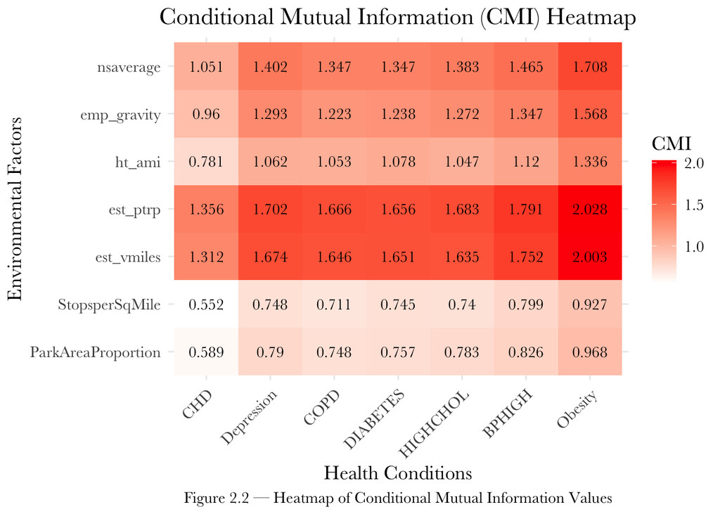

```r
nbins <- sqrt(NROW(data))

numeric_cols <- c(ivs, dvs, 'Lat') # Columns to discretize
discretized_data <- data

for (col in numeric_cols) {
  discretized_data[[col]] <- discretize(discretized_data[[col]], disc = "equalwidth", nbins = nbins)
}

cor_matrix <- cor(discretized_data[numeric_cols], use = "complete.obs")

# Print correlation matrix to understand relationships
# print(cor_matrix)

for (dv in dvs) {
  for (iv in ivs) {
  cond_info <- condinformation(discretized_data[[iv]], discretized_data[[dv]], discretized_data[['State']])
  # print(paste("Conditional Information for", iv, "and", dv, ":", cond_info))
  }
}
cmi_values <- matrix(0, nrow = length(ivs), ncol = length(dvs))
rownames(cmi_values) <- ivs
colnames(cmi_values) <- dvs

for (i in 1:length(ivs)) {
  for (j in 1:length(dvs)) {
    cmi_values[i, j] <- condinformation(discretized_data[[ivs[i]]],
                                        discretized_data[[dvs[j]]],
                                        discretized_data[['State']])
  }
}

# Melt the matrix for ggplot
cmi_melted <- melt(cmi_values)
colnames(cmi_melted) <- c("IV", "DV", "CMI")

# Create the heatmap
ggplot(cmi_melted, aes(x = DV, y = IV, fill = CMI)) +
  geom_tile() +
  geom_text(aes(label = round(CMI, 3)), family = "Baskerville") +
  scale_fill_gradient(low = "white", high = "red") +
  theme_minimal() +
  theme(axis.text.x = element_text(angle = 45, hjust = 1),
        text = element_text(family = "Baskerville", size = 14),
        plot.title = element_text(hjust = 0.5, family = "Baskerville"),
        plot.caption = element_text(hjust = 0.5)) +
  labs(title = "Conditional Mutual Information (CMI) Heatmap",
       x = "Health Conditions",
       y = "Environmental Factors",
       fill = "CMI",
       caption = "Figure 2.2 — Heatmap of Conditional Mutual Information Values")
```

## Models

````r
for (dv in dvs) {
    cat("\n## ", dv, "\n\n")

    cat("### Model Fitting\n\n")

    rds_file <- paste0("fsmodel_", dv, ".rds")
    if (!file.exists(rds_file)) {
      cat(paste("RDS file", rds_file, "not found.\n\n"))
      next
    }

    modG <- readRDS(file = rds_file)
    #plot(modG, residuals = TRUE)

    # TRIAL STUFF

    pred_grid <- expand.grid(
      ht_ami = seq(min(data$ht_ami), max(data$ht_ami), length.out = 100),
      nsaverage = mean(data$nsaverage),
      est_vmiles = mean(data$est_vmiles),
      est_ptrp = mean(data$est_ptrp),
      State = unique(data$State)
    )

    # Make predictions
    preds <- predict(modG, newdata = pred_grid, se.fit = TRUE, type = "terms")

    # Create a data frame for plotting
    plot_data <- data.frame(
      ht_ami = rep(pred_grid$ht_ami, times = length(unique(data$State))),
      State = rep(unique(data$State), each = 100),
      Effect = preds$fit[, "s(ht_ami,nsaverage,State)"],
      SE = preds$se.fit[, "s(ht_ami,nsaverage,State)"]
    )

    # Create the plot
    testplot <- ggplot(plot_data, aes(x = ht_ami, y = Effect, color = State)) +
      geom_line() +
      # geom_ribbon(aes(ymin = Effect - 1.96 * SE,
      #                 ymax = Effect + 1.96 * SE,
      #                 fill = State),
      #             alpha = 0.2) +
      labs(x = "ht_ami", y = "Effect",
          title = "Smooth effect of ht_ami by State") +
      theme_minimal()

    print(testplot)


    cat("\n\n### Model Summary\n\n")
    sum_modG <- summary(modG)
    sum_modG_text <- capture.output(print(sum_modG))
    cat("```\n")
    cat(paste(sum_modG_text, collapse = "\n"))
    cat("\n```\n\n")

    ivlist <- list("est_vmiles", "est_ptrp", "ht_ami", "nsaverage")


    cat("\n### Odds Ratios \n\n")

    format_or_gam <- function(or_data, digits = 3, html = TRUE) {
      # Round numeric columns
      or_data[] <- lapply(or_data, function(x) if(is.numeric(x)) round(x, digits) else x)


        kable(or_data,
              format = "html",
              digits = digits,
              align = c('l', 'r', 'r', 'r', 'r')) %>%
          kable_styling(bootstrap_options = c("striped", "hover"),
                      full_width = FALSE,
                      position = "left") %>%
          row_spec(0, bold = TRUE)
          write.csv(or_data, paste0("/Users/dmach/Downloads/OR_", dv, ".csv"))
      }

    for (iv in ivlist) {
      or <- or_gam(
        data = data,
        model = modG,
        pred = iv,
        percentage = 20,
        slice = TRUE
      )
      f <- format_or_gam(or)
      print(f)
    }

    cat("\n\n")  # Add space between analyses
}
````

[output not shown]

**CHD**

### Model Fitting

RDS file fsmodel_CHD.rds not found.

**Depression**

### Model Fitting

RDS file fsmodel_Depression.rds not found.

**COPD**

### Model Fitting

RDS file fsmodel_COPD.rds not found.

**DIABETES**

### Model Fitting

RDS file fsmodel_DIABETES.rds not found.

**HIGHCHOL**

### Model Fitting

RDS file fsmodel_HIGHCHOL.rds not found.

**BPHIGH**

### Model Fitting

RDS file fsmodel_BPHIGH.rds not found.

**Obesity**

### Model Fitting

RDS file fsmodel_Obesity.rds not found.

### Model Parameters

**CHD**

RDS file fsmodel_CHD.rds not found.

**Depression**

RDS file fsmodel_Depression.rds not found.

**COPD**

RDS file fsmodel_COPD.rds not found.

**DIABETES**

RDS file fsmodel_DIABETES.rds not found.

**HIGHCHOL**

RDS file fsmodel_HIGHCHOL.rds not found.

**BPHIGH**

RDS file fsmodel_BPHIGH.rds not found.

**Obesity**

RDS file fsmodel_Obesity.rds not found.

### Concurvity

```r
for (dv in dvs) {
    cat("\n## ", dv, "\n\n")

    rds_file <- paste0("fsmodel_", dv, ".rds")
    if (!file.exists(rds_file)) {
      cat(paste("RDS file", rds_file, "not found.\n\n"))
      next
    }

    modG <- readRDS(file = rds_file)

    # save / load the concurvity files as RDS

    # cv <- concurvity(modG, full = FALSE)
    # saveRDS(cv, file = paste("concurvity_", dv))

    rdsConc <- paste("concurvity_", dv)
    if (!file.exists(rdsConc)) {
      cat(paste("Concurvity data file", rdsConc, "not found.\n\n"))
      next
    }

    cv <- readRDS(file = rdsConc)
    tablefunct <- function(listMatrix, index) {
      # assign proper type
      if (index == 1) {
        type <- " — Worst"
      }
      else if (index == 2) {
        type <- " — Observed"
      }
      else {
        type <- " — Estimate"
      }

      # now, print the output
      cat(paste("### Concurvity", type, " \n\n"))
      print(
      knitr::kable(listMatrix, format = "html") |>
        kable_styling("striped")
      )
    }

    # make 3 separate tables: worst, observed, estimate (in order)
    i <- 1
    while (i <= 3) {
      tablefunct(cv[[i]], i)
      i <- i + 1
    }


}
```

[output not shown]

**CHD**

RDS file fsmodel_CHD.rds not found.

**Depression**

RDS file fsmodel_Depression.rds not found.

**COPD**

RDS file fsmodel_COPD.rds not found.

**DIABETES**

RDS file fsmodel_DIABETES.rds not found.

**HIGHCHOL**

RDS file fsmodel_HIGHCHOL.rds not found.

**BPHIGH**

RDS file fsmodel_BPHIGH.rds not found.

**Obesity**

RDS file fsmodel_Obesity.rds not found.

## Quasibinomial Model Interpretation

```r
prevalence = exp(linear_predictor) / (1 + exp(linear_predictor))
```